# 01 Final Report

S A Nawash Akhtar

## **Cyclistic bike-share analysis case study**

This case study is a part of Google Data Analytics Certificate. The bike share company “Cyclistic” mentioned in this case study is a fictional company which is based on the “Divvy Bikes” of Chicago.

### **1. Introduction**

In 2016, Cyclistic launched a successful bike-share offering. Since then, the program has grown to a fleet of 5,824 bicycles that are geotracked and locked into a network of 692 stations across Chicago. The bikes can be unlocked from one station and returned to any other station in the system anytime.

Cyclistic has three pricing plan.

- Single-ride pass
- Full-day pass
- Annual membership

Depending on the purchase the company has two user types.

1. **Casual riders** for purchasing Single-ride or Full-day pass
2. **Cyclistic members** for purchasing annual membership

Cyclistic’s finance analysts have concluded that annual members are much more profitable than casual riders. Although the pricing flexibility helps Cyclistic attract more customers. The director of the marketing believes that maximizing the number of annual members will be key to future growth. Rather than creating a marketing campaign that targets all-new customers, the director believes there is a very good chance to convert casual riders into members.

This report will explore the observation based on the data available from “Cyclistic” and will provide recommendations from the analysis and insights.

**Goal:** Design marketing strategies aimed at converting casual riders into annual members.

**Specific task:** Determine how annual members and casual riders use Cyclistic bikes differently.

### **2. Prepare data**

The Cyclistic’s historical trip data is stored on the AWS site and can be used by this licence [Click Here](https://www.divvybikes.com/data-license-agreement). For reference, Cyclistic is a fictional company so “Divvy Bikes” data will be used for this case study.

The data has separate csv files in the aws server for every year and data from Jan’20 to Oct’22 will be used for this analysis. The analysis was done in the month of Nov’22.

In the dataset each ride data is represented by a unique ride id which contains the necessary information for a single ride. The ride data contains the bike type used by the user, start and end station name, start and end station id, user type, start and end time of the trip. Bike stations also have longitude and latitude to locate them.

This first-party data is collected by Cyclistic itself and can be cross-checked with station name and id, location, start and end time to ensure that individual ride data is reliable, accurate and unbiased. For the purposes of this case study, data was analyzed from 2020 to 2022, but beyond these three years, there are over 7 years of ride data stored on AWS servers up to the year 2013. Cyclistic is updating the database on a monthly basis and analysis was done on current data that is relevant to the task. More than 10 million ride data were analyzed over a three-year period containing critical information that helped the analysis reach its final conclusions.

### **3. Process data**

Due to the large amount of data R is used as the primary tool for analysis and visualization. During the data cleaning process, data type mismatches were found especially for the 2020 data, for which the data could not be merged. So the datatype had to be modified for analysis. Also, a new variable named “ride duration” was created to find the difference between ride start and end times. But after analysis, some ride duration values were found to be negative which was not possible. So those values had to be deleted for future use.

The start and end station names were checked and blank values of these variables were removed. Moreover, since the ride ID is unique for each ride, duplicate values were checked and removed accordingly.

All data cleaning processes are explained in the **“Process Data”** file.

### **4. Analyze data**

The task was to find out the different uses of the bike among casual and member riders. Basically, this analysis will determine how users ride the bike differently.

All the analysis processes are explained in the **“Analyze Data”** file.

#### **4.1 Popular days of week**

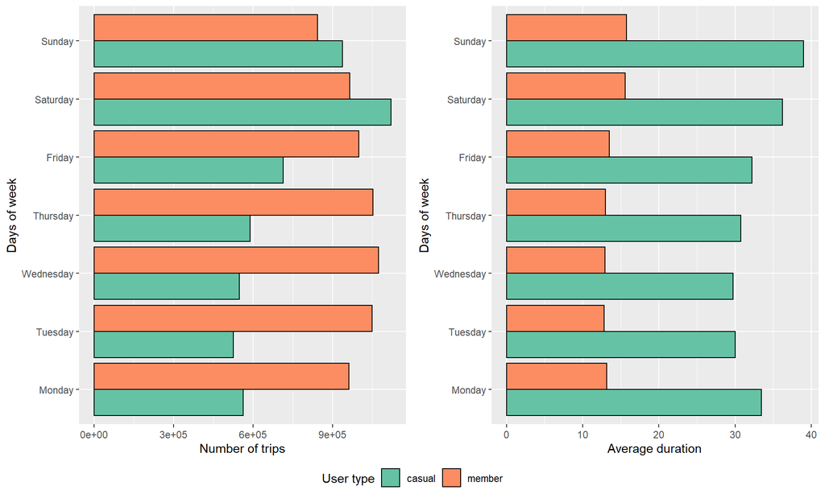

The figure describes how casual and member riders use the bike differently for the days of the week. Here it can be seen that throughout the week, member users ride about the same amount on weekdays and weekends. And for casual users, ride intensity increases on weekends and is almost constant across weekdays but lower than member riders on weekdays. Because members ride bikes for commuting and casual riders mostly bike for leisure.

As for the average times, the times for members are consistently the same throughout the week, and casual riders also have similar levels throughout the week. Here the average duration of casual riders is higher than that of members but the number of trips is higher for members than casual riders.

#### **4.2 Popular months**

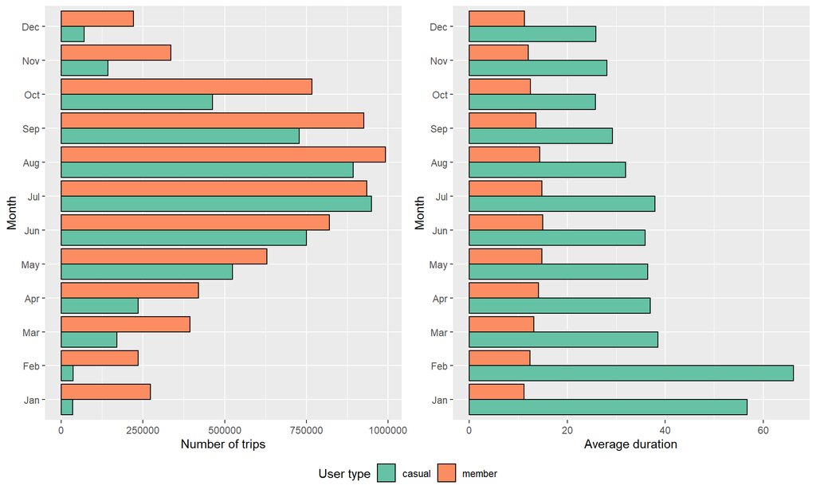

#### **4.3 Popular days of month**

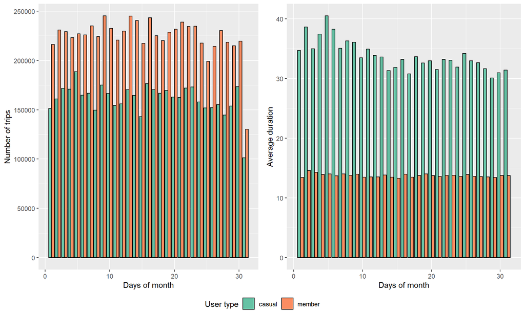

From the figure, we can see that the number of trips and the average duration of monthly usage are almost the same for both riders. It does not drastically change in any circumstances. Although we can say that the number of trips for members is always higher than for casual riders and the average duration is always higher for casual riders than for members.

#### **4.4 Yearly ride data analysis**

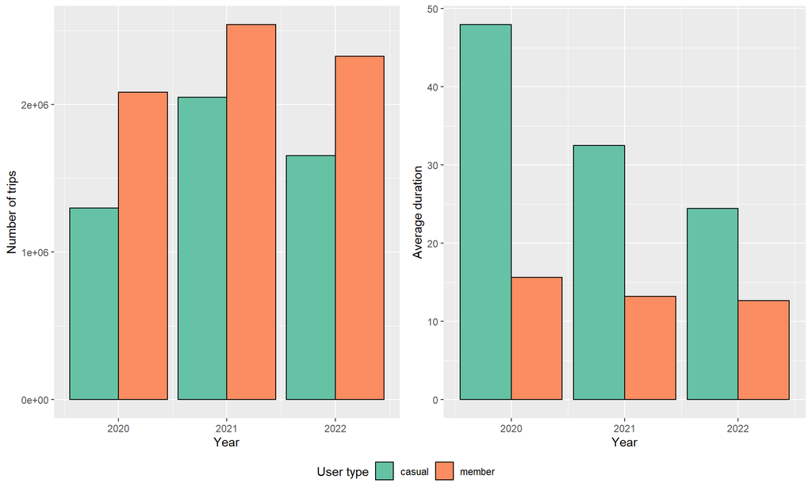

#### **4.5 Bike usage heatmap for days of week and months (2020 - 2022)**

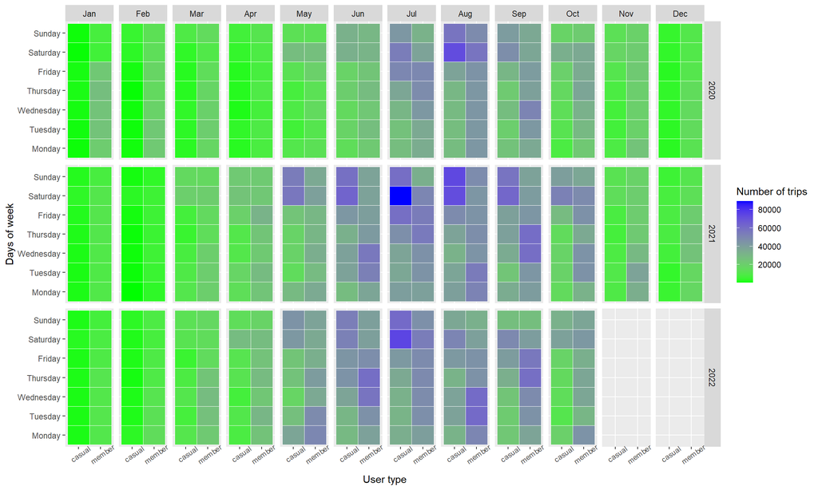

The heat map shows that June, July, August and September are the most popular months for all users. And Saturdays and Sundays are the most popular for casual riders, especially during the summer months. Basically, this means that casual riders mostly use the bike for leisure. Also, members mostly use the bike on weekdays and ramp it up a bit on weekends. During the summer months, members increase their use of a bike for the whole week but interestingly, the days of the week that members use the most during the summer months are Tuesday, Wednesday and Thursday.

#### **4.6 Popular time of the day**

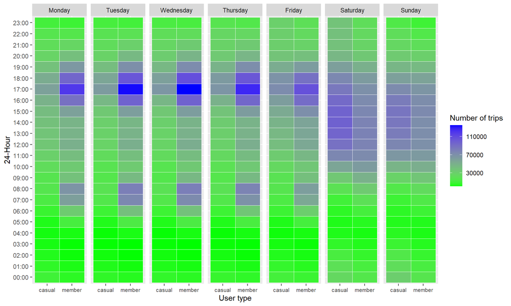

From the figure, we can see that members commute to work using their bikes. It appears that 7am - 8am and 4pm - 7pm are used by most of the members as these are mainly commuting times for the general public. And for this same reason, 5pm is the most popular among members. Also on weekends member users mostly use the bike from 9 am to 7 pm. This shows that they not only use more for commuting but also use bikes for leisure time as well.

Casual riders use the bike from 11 am to 8 pm on weekdays. And rides go up to 1 am on Friday and Saturday nights. This shows that casual riders prefer to take the bike after a night out.

#### **4.7 Most popular station**

| start_station_name | member_casual | number_of_trips | start_lat | start_lng |
| --- | --- | --- | --- | --- |
| Streeter Dr & Grand Ave | casual | 143289 | 41.8923 | -87.6120 |
| Millennium Park | casual | 73360 | 41.8810 | -87.6241 |
| Michigan Ave & Oak St | casual | 64908 | 41.9010 | -87.6238 |
| Clark St & Elm St | member | 62380 | 41.9030 | -87.6313 |
| Kingsbury St & Kinzie St | member | 59873 | 41.8892 | -87.6385 |
| Wells St & Concord Ln | member | 55886 | 41.9121 | -87.6347 |
| Theater on the Lake | casual | 52149 | 41.9263 | -87.6308 |
| Shedd Aquarium | casual | 50196 | 41.8672 | -87.6154 |
| Wells St & Elm St | member | 49550 | 41.9032 | -87.6343 |
| Dearborn St & Erie St | member | 48167 | 41.8940 | -87.6293 |

[interactive chart not shown]

The top three stations for casual users are close to tourist spots. And the number one station for casual users is near Navy Pier. So this confirms the idea that casual riders mainly use the bike for leisure time.

Also, the top three stations for members are around commercial areas and close to any transport stations, especially underground railway stations. So it can be said that members mostly use bike for commuting and they usually come from residential area then use bike to reach their final workplace.

#### **4.8 Most popular bike route**

Average duration and maximum duration are shown in minutes.

##### **4.8.1 Popular route for casual riders**

| member_casual | start_station_name | end_station_name | number_of_trips | average_duration | max_duration |
| --- | --- | --- | --- | --- | --- |
| casual | Streeter Dr & Grand Ave | Streeter Dr & Grand Ave | 27716 | 48.20 | 4035.87 |
| casual | Millennium Park | Millennium Park | 14612 | 49.26 | 10245.48 |
| casual | Michigan Ave & Oak St | Michigan Ave & Oak St | 13878 | 51.81 | 1328.63 |
| casual | Lake Shore Dr & Monroe St | Lake Shore Dr & Monroe St | 10337 | 50.50 | 2874.45 |
| casual | Buckingham Fountain | Buckingham Fountain | 9425 | 67.32 | 8655.93 |
| casual | DuSable Lake Shore Dr & Monroe St | DuSable Lake Shore Dr & Monroe St | 9387 | 37.09 | 1517.80 |
| casual | Indiana Ave & Roosevelt Rd | Indiana Ave & Roosevelt Rd | 8458 | 53.91 | 1607.18 |
| casual | Theater on the Lake | Theater on the Lake | 8229 | 50.00 | 2828.20 |
| casual | DuSable Lake Shore Dr & Monroe St | Streeter Dr & Grand Ave | 7584 | 28.46 | 1431.88 |
| casual | Michigan Ave & 8th St | Michigan Ave & 8th St | 7386 | 55.80 | 2486.65 |

##### **4.8.2 Popular route for members**

| member_casual | start_station_name | end_station_name | number_of_trips | average_duration | max_duration |
| --- | --- | --- | --- | --- | --- |
| member | Ellis Ave & 60th St | Ellis Ave & 55th St | 9314 | 5.58 | 1148.15 |
| member | Ellis Ave & 60th St | University Ave & 57th St | 8716 | 5.48 | 1506.53 |
| member | Ellis Ave & 55th St | Ellis Ave & 60th St | 8366 | 5.67 | 724.32 |
| member | University Ave & 57th St | Ellis Ave & 60th St | 8293 | 5.20 | 1106.27 |
| member | State St & 33rd St | Calumet Ave & 33rd St | 5341 | 4.70 | 1010.73 |
| member | Calumet Ave & 33rd St | State St & 33rd St | 5295 | 4.34 | 1144.65 |
| member | Loomis St & Lexington St | Morgan St & Polk St | 4966 | 5.60 | 86.57 |
| member | Morgan St & Polk St | Loomis St & Lexington St | 4728 | 6.17 | 782.73 |
| member | University Ave & 57th St | Kimbark Ave & 53rd St | 4025 | 7.79 | 455.05 |
| member | MLK Jr Dr & 29th St | State St & 33rd St | 3842 | 7.82 | 180.40 |

##### **4.8.3 Bike route visualization**

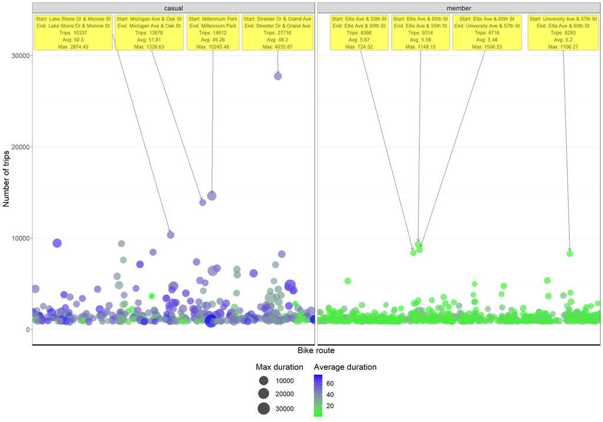

#### **4.9 Bike type preference**

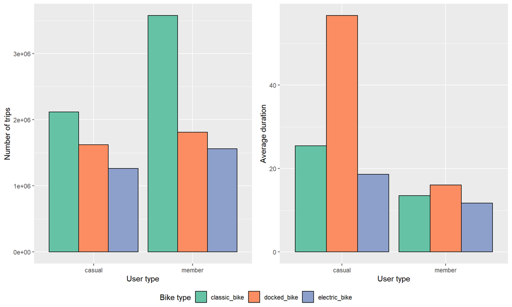

From the figure, it can be seen that there are three different bike types for Cyclistic. Both casual riders and members use classic bikes the most followed by docked bikes and electric bikes. From usage, it can be assumed that the classic bike is the cheapest among them. But interestingly docked bikes are used more on average duration basis and preferred by most users for its price and comfort.

### **5. Recommendations**

The project brief states that the focus should be pointed to the different uses of the bike and the ultimate goal is to encourage casual riders to convert to member users.

Based on the analysis, some recommendations can be given to Cyclistic.